- Home
- Sobre
- Análise de Dados

# Análise de Dados da Criminalidade em Salvador

A violência no Brasil é um problema persistente que atinge direta ou indiretamente a população. O país tem níveis acima da média mundial no que se refere a crimes violentos, com níveis particularmente altos no tocante a violência armada e homicídios. Em 2016, o Brasil alcançou a marca histórica de 62 517 homicídios, segundo informações do Ministério da Saúde. Isso equivale a uma taxa de 30,3 mortes para cada 100 mil habitantes, uma das mais altas taxas de homicídios intencionais do mundo.O limite considerado como suportável pela Organização Mundial da Saúde (OMS) é de 10 homicídios por 100 mil habitantes.

fonte: [Wikipedia](https://pt.wikipedia.org/wiki/Viol%C3%AAncia_no_Brasil)

## Origem da base de dados

Essa base de dados,tem sua origem no site da Secretaria de Segurança Pública, possuimos aqui amostra de crimes que aconteceram em Salvador de Janeiro de 2014 até Março de 2018. Com base nas informações dessa base de dados, irei levantar questionamentos e responde-los

- [SSP-BA Estatística 2014](http://www.ssp.ba.gov.br/modules/conteudo/conteudo.php?conteudo=36)
- [SSP-BA Estatística 2015](http://www.ssp.ba.gov.br/modules/conteudo/conteudo.php?conteudo=21)
- [SSP-BA Estatística 2016](http://www.ssp.ba.gov.br/modules/conteudo/conteudo.php?conteudo=69)
- [SSP-BA Estatística 2017](http://www.ssp.ba.gov.br/modules/conteudo/conteudo.php?conteudo=90)
- [SSP-BA Estatística 2018](http://www.ssp.ba.gov.br/modules/conteudo/conteudo.php?conteudo=97)

## Perguntas

- Qual o valor total por tipo de crime e dividido por ano?
- Qual a evolução por tipo de crime durante os períodos pesquisado(2014 a 2017)?
- Qual o total de mortes nos anos de 2014 até 2017?

**Vamos importar as bibliotecas necessárias converter os arquivos pdf em csv e carregar os arquivos csv e investigar os dados**

```python
#-> Importando bibliotecas necessárias
import pdftables_api as pdf
import pandas as pd
import numpy as np
import matplotlib.pyplot as plt
import seaborn as sns
% matplotlib inline
```

```python
# Função para converter os arquivos pdf em csv
def converter(input_pdf, output_csv):
    """Converter tabelas PDF em tabelas CSV
      Argumentos:
          input_pdf: arquivo/tabela em PDF.
          output_csv: saída do aquivo em CSV.
      Retorna:
          Um arquivo/tabela no formato CSV"""
    c = pdf.Client('wu41gv9rxszo')
    c.csv(input_pdf, output_csv)
```

```python
#Ativando a função de conversão
converter('03CAPITAL2014.pdf', '2014.csv')
converter('03CAPITAL2015.pdf', '2015.csv')
converter('03CAPITAL2016.pdf', '2016.csv')
converter('03_CAPITAL_2017_JAN_A_DEZ.pdf', '2017.csv')
converter('03_CAPITAL_2018_JAN_A_MAR.pdf', '2018.csv')
```

```python
#Carregando o arquivo de dados
ds2014 = pd.read_csv('2014.csv')
ds2015 = pd.read_csv('2015.csv')
ds2016 = pd.read_csv('2016.csv')
ds2017 = pd.read_csv('2017.csv')
ds2018 = pd.read_csv('2018.csv')

#Verificando os dados carregados de 2014
ds2014
```

|  | SECRETARIA DA SEGURANÇA PÚBLICA | Unnamed: 1 | Unnamed: 2 | Unnamed: 3 | Unnamed: 4 | Unnamed: 5 | Unnamed: 6 | Unnamed: 7 | Unnamed: 8 | Unnamed: 9 |
| --- | --- | --- | --- | --- | --- | --- | --- | --- | --- | --- |
| 0 | PRINCIPAIS DELITOS - CAPITAL | NaN | NaN | NaN | NaN | NaN | NaN | NaN | NaN | NaN |
| 1 | Período: 01/01/2014 à 31/12/2014 | NaN | NaN | NaN | NaN | NaN | NaN | NaN | NaN | NaN |
| 2 | NaN | NaN | NaN | NaN | NaN | NaN | NaN | NaN | NaN | Uso/Porte |
| 3 | NaN | NaN | Lesão Corporal | Roubo com | NaN | NaN | Roubo a Ônibus | NaN | NaN | NaN |
| 4 | Área Integrada de Segurança | Homicídio | NaN | NaN | Tentativa de | NaN | NaN | Roubo de | NaN | Substância |
| 5 | NaN | NaN | Seguida de | Resultado Morte | NaN | Estupro | (Urbano e em | NaN | Furto de Veículo | NaN |
| 6 | Pública - AISP | Doloso | NaN | NaN | Homicídio | NaN | NaN | Veículo | NaN | Entorpecente |
| 7 | NaN | NaN | Morte | - (Latrocínio) | NaN | NaN | Rodovia) | NaN | NaN | NaN |
| 8 | NaN | NaN | NaN | NaN | NaN | NaN | NaN | NaN | NaN | (Usuários) |
| 9 | AISP 06 - Brotas | 69 | 0 | 4 | 43 | 21 | 205 | 568 | 150 | 74 |
| 10 | AISP 07 - Rio Vermelho | 18 | 2 | 3 | 13 | 21 | 106 | 287 | 63 | 107 |
| 11 | AISP 09 - Boca do Rio | 16 | 1 | 1 | 12 | 13 | 57 | 562 | 64 | 24 |
| 12 | AISP 12 - Itapuã | 152 | 2 | 8 | 44 | 62 | 168 | 832 | 234 | 132 |
| 13 | AISP 14 - Barra | 4 | 1 | 0 | 1 | 5 | 33 | 80 | 28 | 35 |
| 14 | AISP 15 - Nordeste | 15 | 0 | 0 | 6 | 12 | 61 | 20 | 7 | 33 |
| 15 | AISP 16 - Pituba | 7 | 0 | 0 | 10 | 7 | 114 | 358 | 38 | 31 |
| 16 | RISP ATLÂNTICO | 281 | 6 | 16 | 129 | 141 | 744 | 2.707 | 584 | 436 |
| 17 | AISP 01 - Barris | 36 | 1 | 4 | 18 | 22 | 107 | 291 | 120 | 119 |
| 18 | AISP 02 - Liberdade | 124 | 3 | 3 | 56 | 35 | 93 | 545 | 191 | 56 |
| 19 | AISP 03 - Bonfim | 83 | 3 | 3 | 54 | 27 | 125 | 372 | 246 | 65 |
| 20 | AISP 04 - São Caetano | 124 | 2 | 7 | 26 | 55 | 149 | 431 | 85 | 37 |
| 21 | AISP 05 - Periperi | 235 | 5 | 6 | 156 | 82 | 175 | 395 | 70 | 52 |
| 22 | AISP 08 - CIA | 29 | 0 | 1 | 7 | 6 | 12 | 147 | 22 | 9 |
| 23 | RISP BTS | 631 | 14 | 24 | 317 | 227 | 661 | 2.181 | 734 | 338 |
| 24 | AISP 10 - Pau da Lima | 108 | 2 | 4 | 64 | 35 | 147 | 533 | 160 | 35 |
| 25 | AISP 11 - Tancredo Neves | 200 | 3 | 5 | 125 | 86 | 333 | 713 | 219 | 103 |
| 26 | AISP 13 - Cajazeiras | 101 | 1 | 1 | 77 | 43 | 44 | 239 | 55 | 18 |
| 27 | RISP CENTRAL | 409 | 6 | 10 | 266 | 164 | 524 | 1.485 | 434 | 156 |
| 28 | TOTAL DA CAPITAL | 1.321 | 26 | 50 | 712 | 532 | 1.929 | 6.373 | 1.752 | 930 |
| 29 | Fonte: SSP-BA | NaN | NaN | NaN | NaN | NaN | NaN | NaN | NaN | NaN |
| 30 | * Dados coletados em 09/10/2015 às 09h30min | NaN | NaN | NaN | NaN | NaN | NaN | NaN | NaN | NaN |

```python
#Verificando os dados carregados de 2015, 2016, 2017 e 2018
print(ds2015.head())
print(ds2016.head())
print(ds2017.head())
print(ds2018.head())
```

```
    SECRETARIA DA SEGURANÇA PÚBLICA Unnamed: 1      Unnamed: 2 Unnamed: 3  \
0      PRINCIPAIS DELITOS - CAPITAL        NaN             NaN        NaN
1  Período: 01/01/2015 à 31/12/2015        NaN             NaN        NaN
2                               NaN        NaN             NaN        NaN
3                               NaN        NaN  Lesão Corporal  Roubo com
4       Área Integrada de Segurança  Homicídio             NaN        NaN

     Unnamed: 4 Unnamed: 5      Unnamed: 6 Unnamed: 7 Unnamed: 8  Unnamed: 9
0           NaN        NaN             NaN        NaN        NaN         NaN
1           NaN        NaN             NaN        NaN        NaN         NaN
2           NaN        NaN             NaN        NaN        NaN   Uso/Porte
3           NaN        NaN  Roubo a Ônibus        NaN        NaN         NaN
4  Tentativa de        NaN             NaN   Roubo de        NaN  Substância
    SECRETARIA DA SEGURANÇA PÚBLICA Unnamed: 1      Unnamed: 2 Unnamed: 3  \
0      PRINCIPAIS DELITOS - CAPITAL        NaN             NaN        NaN
```

[output cut: 37 more lines]

```python
#Avaliando os dados 2014
ds2014.info()
```

```
<class 'pandas.core.frame.DataFrame'>
RangeIndex: 31 entries, 0 to 30
Data columns (total 10 columns):
SECRETARIA DA SEGURANÇA PÚBLICA    26 non-null object
Unnamed: 1                         22 non-null object
Unnamed: 2                         23 non-null object
Unnamed: 3                         23 non-null object
Unnamed: 4                         22 non-null object
Unnamed: 5                         21 non-null object
Unnamed: 6                         23 non-null object
Unnamed: 7                         22 non-null object
Unnamed: 8                         21 non-null object
Unnamed: 9                         24 non-null object
dtypes: object(10)
memory usage: 2.5+ KB
```

```python
#Avaliando os dados 2018
ds2018.info()
```

```
<class 'pandas.core.frame.DataFrame'>
RangeIndex: 31 entries, 0 to 30
Data columns (total 10 columns):
SECRETARIA DA SEGURANÇA PÚBLICA    26 non-null object
Unnamed: 1                         22 non-null object
Unnamed: 2                         23 non-null object
Unnamed: 3                         23 non-null object
Unnamed: 4                         22 non-null object
Unnamed: 5                         21 non-null object
Unnamed: 6                         23 non-null object
Unnamed: 7                         22 non-null object
Unnamed: 8                         21 non-null object
Unnamed: 9                         24 non-null object
dtypes: object(10)
memory usage: 2.5+ KB
```

```python
#numero de amostras  (linhas e colunas)
def amostras(ds, ano):
    """Mostra os valores de amostras e colunas do arquivo
      Argumentos:
          ds: Lista/base de dados.
          ano: Ano do arquivo
      Retorna:
          Um print informando os valores de amostras e colunas do arquivo."""
    print("O arquivo {0} possui {1} amostras e {2} colunas".format(
        ano, ds.shape[0], ds.shape[1] ))
amostras(ds2014, 2014)
amostras(ds2015, 2015)
amostras(ds2016, 2016)
amostras(ds2017, 2017)
amostras(ds2018, 2018)
```

```
O arquivo 2014 possui 31 amostras e 10 colunas
O arquivo 2015 possui 31 amostras e 10 colunas
O arquivo 2016 possui 31 amostras e 10 colunas
O arquivo 2017 possui 31 amostras e 10 colunas
O arquivo 2018 possui 31 amostras e 10 colunas
```

```python
#Colunas com valores faltantes 2014
print("Colunas com valores Faltantes: \n {0} \n".format(
    ds2014.columns[ds2014.isnull().any()].values))
```

```
Colunas com valores Faltantes:
 ['SECRETARIA DA SEGURANÇA PÚBLICA' 'Unnamed: 1' 'Unnamed: 2' 'Unnamed: 3'
 'Unnamed: 4' 'Unnamed: 5' 'Unnamed: 6' 'Unnamed: 7' 'Unnamed: 8'
 'Unnamed: 9']
```

```python
#linhas duplicadas 2014
print(" Duplicadas: {0} ".format(
        ds2014.duplicated().sum()))

#linhas duplicadas 2018
print(" Duplicadas: {0} ".format(
        ds2018.duplicated().sum()))
```

```
 Duplicadas: 0
 Duplicadas: 0
```

```python
#Verificando a quantidade de valores unicos em cada coluna 2014
ds2014.nunique()
```

```
SECRETARIA DA SEGURANÇA PÚBLICA    26
Unnamed: 1                         21
Unnamed: 2                         11
Unnamed: 3                         15
Unnamed: 4                         22
Unnamed: 5                         19
Unnamed: 6                         23
Unnamed: 7                         22
Unnamed: 8                         21
Unnamed: 9                         23
dtype: int64
```

```python
#Verificando a quantidade de valores unicos em cada coluna 2015
ds2015.nunique()
```

```
SECRETARIA DA SEGURANÇA PÚBLICA    26
Unnamed: 1                         21
Unnamed: 2                         13
Unnamed: 3                         14
Unnamed: 4                         20
Unnamed: 5                         18
Unnamed: 6                         23
Unnamed: 7                         22
Unnamed: 8                         19
Unnamed: 9                         22
dtype: int64
```

```python
#Verificando a quantidade de valores unicos em cada coluna 2016
ds2016.nunique()
```

```
SECRETARIA DA SEGURANÇA PÚBLICA    26
Unnamed: 1                         21
Unnamed: 2                         11
Unnamed: 3                         14
Unnamed: 4                         22
Unnamed: 5                         17
Unnamed: 6                         23
Unnamed: 7                         22
Unnamed: 8                         21
Unnamed: 9                         22
dtype: int64
```

```python
#Verificando a quantidade de valores unicos em cada coluna 2017
ds2017.nunique()
```

```
SECRETARIA DA SEGURANÇA PÚBLICA    26
Unnamed: 1                         20
Unnamed: 2                          9
Unnamed: 3                         13
Unnamed: 4                         21
Unnamed: 5                         19
Unnamed: 6                         23
Unnamed: 7                         22
Unnamed: 8                         21
Unnamed: 9                         22
dtype: int64
```

```python
#Verificando a quantidade de valores unicos em cada coluna 2018
ds2018.nunique()
```

```
SECRETARIA DA SEGURANÇA PÚBLICA    26
Unnamed: 1                         19
Unnamed: 2                          5
Unnamed: 3                          6
Unnamed: 4                         16
Unnamed: 5                         14
Unnamed: 6                         19
Unnamed: 7                         22
Unnamed: 8                         17
Unnamed: 9                         22
dtype: int64
```

**Agora que já conhecemos os nossos dados vamos a próxima etapa.**

## Limpeza dos dados

```python
# Excluindo as linhas com valores nulos
ds2014 = ds2014.dropna(axis=0)
ds2015 = ds2015.dropna(axis=0)
ds2016 = ds2016.dropna(axis=0)
ds2017 = ds2017.dropna(axis=0)
ds2018 = ds2018.dropna(axis=0)
```

```python
#Vamos verificar como ficou a tabela de 2014
ds2014.head()
```

|  | SECRETARIA DA SEGURANÇA PÚBLICA | Unnamed: 1 | Unnamed: 2 | Unnamed: 3 | Unnamed: 4 | Unnamed: 5 | Unnamed: 6 | Unnamed: 7 | Unnamed: 8 | Unnamed: 9 |
| --- | --- | --- | --- | --- | --- | --- | --- | --- | --- | --- |
| 9 | AISP 06 - Brotas | 69 | 0 | 4 | 43 | 21 | 205 | 568 | 150 | 74 |
| 10 | AISP 07 - Rio Vermelho | 18 | 2 | 3 | 13 | 21 | 106 | 287 | 63 | 107 |
| 11 | AISP 09 - Boca do Rio | 16 | 1 | 1 | 12 | 13 | 57 | 562 | 64 | 24 |
| 12 | AISP 12 - Itapuã | 152 | 2 | 8 | 44 | 62 | 168 | 832 | 234 | 132 |
| 13 | AISP 14 - Barra | 4 | 1 | 0 | 1 | 5 | 33 | 80 | 28 | 35 |

```python
#Agora vamos melhora os nomes das colunas
new_labels = ['aisp', 'homicídio doloso', 'lesão corporal seguida de morte', 'latrocínio', 'tentativa de homicídio', 'estupro', 'roubo a ônibus', 'roubo de veículo', 'furto de veículo', 'uso/porte substância entorpecente ']
#Função para novos nomes nas colunas
def name_columns(df):
    """Incluir novas labels nas colunas
      Argumentos:
          df: Lista/base de dados.
      Retorna:
          Lista/base de dados."""
    df.columns = new_labels
```

```python
name_columns(ds2014)
name_columns(ds2015)
name_columns(ds2016)
name_columns(ds2017)
name_columns(ds2018)
```

```python
#Verificando se as alterações foram realizadas
ds2015.head()
```

|  | aisp | homicídio doloso | lesão corporal seguida de morte | latrocínio | tentativa de homicídio | estupro | roubo a ônibus | roubo de veículo | furto de veículo | uso/porte substância entorpecente |
| --- | --- | --- | --- | --- | --- | --- | --- | --- | --- | --- |
| 9 | AISP 06 - Brotas | 60 | 3 | 5 | 22 | 31 | 190 | 493 | 133 | 77 |
| 10 | AISP 07 - Rio Vermelho | 24 | 1 | 1 | 33 | 18 | 153 | 241 | 58 | 41 |
| 11 | AISP 09 - Boca do Rio | 25 | 1 | 4 | 25 | 31 | 49 | 596 | 67 | 90 |
| 12 | AISP 12 - Itapuã | 119 | 3 | 6 | 18 | 49 | 218 | 871 | 189 | 79 |
| 13 | AISP 14 - Barra | 2 | 1 | 2 | 4 | 9 | 28 | 82 | 14 | 47 |

```python
#Vamos verificar se tem açguma coluna com valores faltantes
print("Colunas com valores Faltantes: \n {0} \n".format(
    ds2016.columns[ds2016.isnull().any()].values))
```

```
Colunas com valores Faltantes:
 []
```

```python
#Criando colunas do ano
# Criando vetor de ano para o dataframe
def ano_vetor(ano, ds):
    """Realizar uma lista com valores do ano
      Argumentos:
          ano: Valor do ano a ser incluído.
          ds: Lista/base de dados
      Retorna:
          Vetor/Lista com os valores do ano desejado."""
    x_ano = np.repeat(ano, ds.shape[0])
    return x_ano

ano_2014=ano_vetor(2014, ds2014)
print(ano_2014)

ano_2015=ano_vetor(2015, ds2015)
print(ano_2015)

ano_2016=ano_vetor(2016, ds2016)
print(ano_2016)

ano_2017=ano_vetor(2017, ds2017)
print(ano_2017)

ano_2018=ano_vetor(2018, ds2018)
print(ano_2018)
```

```
[2014 2014 2014 2014 2014 2014 2014 2014 2014 2014 2014 2014 2014 2014
 2014 2014 2014 2014 2014 2014]
[2015 2015 2015 2015 2015 2015 2015 2015 2015 2015 2015 2015 2015 2015
 2015 2015 2015 2015 2015 2015]
[2016 2016 2016 2016 2016 2016 2016 2016 2016 2016 2016 2016 2016 2016
 2016 2016 2016 2016 2016 2016]
[2017 2017 2017 2017 2017 2017 2017 2017 2017 2017 2017 2017 2017 2017
 2017 2017 2017 2017 2017 2017]
[2018 2018 2018 2018 2018 2018 2018 2018 2018 2018 2018 2018 2018 2018
 2018 2018 2018 2018 2018 2018]
```

```python
#Adicionando os vetores a nova coluna de Ano
ds2014['ano'] = ano_2014
ds2015['ano'] = ano_2015
ds2016['ano'] = ano_2016
ds2017['ano'] = ano_2017
ds2018['ano'] = ano_2018
ds2014.head()
```

|  | aisp | homicídio doloso | lesão corporal seguida de morte | latrocínio | tentativa de homicídio | estupro | roubo a ônibus | roubo de veículo | furto de veículo | uso/porte substância entorpecente | ano |
| --- | --- | --- | --- | --- | --- | --- | --- | --- | --- | --- | --- |
| 9 | AISP 06 - Brotas | 69 | 0 | 4 | 43 | 21 | 205 | 568 | 150 | 74 | 2014 |
| 10 | AISP 07 - Rio Vermelho | 18 | 2 | 3 | 13 | 21 | 106 | 287 | 63 | 107 | 2014 |
| 11 | AISP 09 - Boca do Rio | 16 | 1 | 1 | 12 | 13 | 57 | 562 | 64 | 24 | 2014 |
| 12 | AISP 12 - Itapuã | 152 | 2 | 8 | 44 | 62 | 168 | 832 | 234 | 132 | 2014 |
| 13 | AISP 14 - Barra | 4 | 1 | 0 | 1 | 5 | 33 | 80 | 28 | 35 | 2014 |

```python
#Combinndo os dataframes em um só
ds_total = ds2014.append(ds2015)
ds_total = ds_total.append(ds2016)
ds_total = ds_total.append(ds2017)
ds_total = ds_total.append(ds2018)

ds_total
```

|  | aisp | homicídio doloso | lesão corporal seguida de morte | latrocínio | tentativa de homicídio | estupro | roubo a ônibus | roubo de veículo | furto de veículo | uso/porte substância entorpecente | ano |
| --- | --- | --- | --- | --- | --- | --- | --- | --- | --- | --- | --- |
| 9 | AISP 06 - Brotas | 69 | 0 | 4 | 43 | 21 | 205 | 568 | 150 | 74 | 2014 |
| 10 | AISP 07 - Rio Vermelho | 18 | 2 | 3 | 13 | 21 | 106 | 287 | 63 | 107 | 2014 |
| 11 | AISP 09 - Boca do Rio | 16 | 1 | 1 | 12 | 13 | 57 | 562 | 64 | 24 | 2014 |
| 12 | AISP 12 - Itapuã | 152 | 2 | 8 | 44 | 62 | 168 | 832 | 234 | 132 | 2014 |
| 13 | AISP 14 - Barra | 4 | 1 | 0 | 1 | 5 | 33 | 80 | 28 | 35 | 2014 |
| 14 | AISP 15 - Nordeste | 15 | 0 | 0 | 6 | 12 | 61 | 20 | 7 | 33 | 2014 |
| 15 | AISP 16 - Pituba | 7 | 0 | 0 | 10 | 7 | 114 | 358 | 38 | 31 | 2014 |
| 16 | RISP ATLÂNTICO | 281 | 6 | 16 | 129 | 141 | 744 | 2.707 | 584 | 436 | 2014 |
| 17 | AISP 01 - Barris | 36 | 1 | 4 | 18 | 22 | 107 | 291 | 120 | 119 | 2014 |
| 18 | AISP 02 - Liberdade | 124 | 3 | 3 | 56 | 35 | 93 | 545 | 191 | 56 | 2014 |
| 19 | AISP 03 - Bonfim | 83 | 3 | 3 | 54 | 27 | 125 | 372 | 246 | 65 | 2014 |
| 20 | AISP 04 - São Caetano | 124 | 2 | 7 | 26 | 55 | 149 | 431 | 85 | 37 | 2014 |
| 21 | AISP 05 - Periperi | 235 | 5 | 6 | 156 | 82 | 175 | 395 | 70 | 52 | 2014 |
| 22 | AISP 08 - CIA | 29 | 0 | 1 | 7 | 6 | 12 | 147 | 22 | 9 | 2014 |
| 23 | RISP BTS | 631 | 14 | 24 | 317 | 227 | 661 | 2.181 | 734 | 338 | 2014 |
| 24 | AISP 10 - Pau da Lima | 108 | 2 | 4 | 64 | 35 | 147 | 533 | 160 | 35 | 2014 |
| 25 | AISP 11 - Tancredo Neves | 200 | 3 | 5 | 125 | 86 | 333 | 713 | 219 | 103 | 2014 |
| 26 | AISP 13 - Cajazeiras | 101 | 1 | 1 | 77 | 43 | 44 | 239 | 55 | 18 | 2014 |
| 27 | RISP CENTRAL | 409 | 6 | 10 | 266 | 164 | 524 | 1.485 | 434 | 156 | 2014 |
| 28 | TOTAL DA CAPITAL | 1.321 | 26 | 50 | 712 | 532 | 1.929 | 6.373 | 1.752 | 930 | 2014 |
| 9 | AISP 06 - Brotas | 60 | 3 | 5 | 22 | 31 | 190 | 493 | 133 | 77 | 2015 |
| 10 | AISP 07 - Rio Vermelho | 24 | 1 | 1 | 33 | 18 | 153 | 241 | 58 | 41 | 2015 |
| 11 | AISP 09 - Boca do Rio | 25 | 1 | 4 | 25 | 31 | 49 | 596 | 67 | 90 | 2015 |
| 12 | AISP 12 - Itapuã | 119 | 3 | 6 | 18 | 49 | 218 | 871 | 189 | 79 | 2015 |
| 13 | AISP 14 - Barra | 2 | 1 | 2 | 4 | 9 | 28 | 82 | 14 | 47 | 2015 |
| 14 | AISP 15 - Nordeste | 10 | 2 | 2 | 15 | 9 | 69 | 17 | 14 | 57 | 2015 |
| 15 | AISP 16 - Pituba | 2 | 0 | 1 | 5 | 10 | 84 | 380 | 38 | 52 | 2015 |
| 16 | RISP ATLÂNTICO | 242 | 11 | 21 | 122 | 157 | 791 | 2.680 | 513 | 443 | 2015 |
| 17 | AISP 01 - Barris | 53 | 1 | 5 | 37 | 22 | 159 | 293 | 126 | 85 | 2015 |
| 18 | AISP 02 - Liberdade | 110 | 2 | 1 | 48 | 32 | 143 | 496 | 149 | 21 | 2015 |
| ... | ... | ... | ... | ... | ... | ... | ... | ... | ... | ... | ... |
| 19 | AISP 03 - Bonfim | 91 | 1 | 4 | 46 | 52 | 327 | 282 | 191 | 93 | 2017 |
| 20 | AISP 04 - São Caetano | 131 | 1 | 4 | 43 | 39 | 289 | 489 | 92 | 55 | 2017 |
| 21 | AISP 05 - Periperi | 243 | 0 | 5 | 96 | 82 | 342 | 423 | 81 | 104 | 2017 |
| 22 | AISP 08 - CIA | 34 | 1 | 0 | 14 | 6 | 38 | 134 | 9 | 111 | 2017 |
| 23 | RISP BTS | 651 | 7 | 16 | 300 | 227 | 1.269 | 1.996 | 566 | 554 | 2017 |
| 24 | AISP 10 - Pau da Lima | 128 | 1 | 3 | 32 | 48 | 87 | 495 | 137 | 23 | 2017 |
| 25 | AISP 11 - Tancredo Neves | 135 | 1 | 4 | 49 | 84 | 347 | 629 | 209 | 230 | 2017 |
| 26 | AISP 13 - Cajazeiras | 128 | 0 | 4 | 21 | 48 | 85 | 366 | 50 | 79 | 2017 |
| 27 | RISP CENTRAL | 391 | 2 | 11 | 102 | 180 | 519 | 1.490 | 396 | 332 | 2017 |
| 28 | TOTAL DA CAPITAL | 1.346 | 12 | 36 | 523 | 576 | 2.615 | 5.733 | 1.565 | 1.533 | 2017 |
| 9 | AISP 06 - Brotas | 17 | 0 | 1 | 9 | 0 | 34 | 90 | 22 | 16 | 2018 |
| 10 | AISP 07 - Rio Vermelho | 3 | 0 | 0 | 5 | 2 | 27 | 57 | 24 | 41 | 2018 |
| 11 | AISP 09 - Boca do Rio | 9 | 0 | 0 | 1 | 5 | 14 | 122 | 29 | 26 | 2018 |
| 12 | AISP 12 - Itapuã | 30 | 0 | 0 | 3 | 3 | 11 | 138 | 56 | 4 | 2018 |
| 13 | AISP 14 - Barra | 1 | 0 | 0 | 0 | 0 | 4 | 10 | 5 | 15 | 2018 |
| 14 | AISP 15 - Nordeste | 7 | 0 | 0 | 3 | 2 | 7 | 5 | 3 | 19 | 2018 |
| 15 | AISP 16 - Pituba | 1 | 0 | 0 | 0 | 0 | 34 | 62 | 20 | 23 | 2018 |
| 16 | RISP ATLÂNTICO | 68 | 0 | 1 | 21 | 12 | 131 | 484 | 159 | 144 | 2018 |
| 17 | AISP 01 - Barris | 8 | 0 | 0 | 9 | 4 | 13 | 55 | 13 | 69 | 2018 |
| 18 | AISP 02 - Liberdade | 37 | 0 | 0 | 12 | 3 | 21 | 133 | 16 | 12 | 2018 |
| 19 | AISP 03 - Bonfim | 24 | 0 | 0 | 14 | 9 | 35 | 78 | 42 | 22 | 2018 |
| 20 | AISP 04 - São Caetano | 18 | 0 | 0 | 2 | 12 | 58 | 155 | 16 | 15 | 2018 |
| 21 | AISP 05 - Periperi | 44 | 1 | 1 | 17 | 10 | 58 | 82 | 24 | 12 | 2018 |
| 22 | AISP 08 - CIA | 10 | 0 | 0 | 1 | 2 | 15 | 40 | 3 | 28 | 2018 |
| 23 | RISP BTS | 141 | 1 | 1 | 55 | 40 | 200 | 543 | 114 | 158 | 2018 |
| 24 | AISP 10 - Pau da Lima | 20 | 0 | 0 | 3 | 7 | 27 | 124 | 32 | 6 | 2018 |
| 25 | AISP 11 - Tancredo Neves | 37 | 0 | 0 | 6 | 8 | 79 | 170 | 31 | 34 | 2018 |
| 26 | AISP 13 - Cajazeiras | 18 | 0 | 0 | 6 | 4 | 34 | 104 | 16 | 13 | 2018 |
| 27 | RISP CENTRAL | 75 | 0 | 0 | 15 | 19 | 140 | 398 | 79 | 53 | 2018 |
| 28 | TOTAL DA CAPITAL | 284 | 1 | 2 | 91 | 71 | 471 | 1.425 | 352 | 355 | 2018 |

100 rows × 11 columns

```python
# converta as colunas  para int
def converter_int(df):
    """Converter valores do tipo string em int
      Argumentos:
          df: Lista/base de dados
      Retorna:
          Uma validação de que os valores foram transformados em inteiros."""
    df=df.str.extract('(\d+)').astype(int)
    return df.info()
```

```python
converter_int(ds_total['homicídio doloso'])
converter_int(ds_total['lesão corporal seguida de morte'])
converter_int(ds_total['latrocínio'])
converter_int(ds_total['tentativa de homicídio'])
converter_int(ds_total['estupro'])
converter_int(ds_total['roubo a ônibus'])
converter_int(ds_total['roubo de veículo'])
converter_int(ds_total['furto de veículo'])
```

```
<class 'pandas.core.frame.DataFrame'>
Int64Index: 100 entries, 9 to 28
Data columns (total 1 columns):
0    100 non-null int32
dtypes: int32(1)
memory usage: 1.2 KB
<class 'pandas.core.frame.DataFrame'>
Int64Index: 100 entries, 9 to 28
Data columns (total 1 columns):
0    100 non-null int32
dtypes: int32(1)
memory usage: 1.2 KB
<class 'pandas.core.frame.DataFrame'>
Int64Index: 100 entries, 9 to 28
Data columns (total 1 columns):
0    100 non-null int32
dtypes: int32(1)
memory usage: 1.2 KB
<class 'pandas.core.frame.DataFrame'>
Int64Index: 100 entries, 9 to 28
Data columns (total 1 columns):
0    100 non-null int32
dtypes: int32(1)
memory usage: 1.2 KB
<class 'pandas.core.frame.DataFrame'>
Int64Index: 100 entries, 9 to 28
Data columns (total 1 columns):
0    100 non-null int32
dtypes: int32(1)
memory usage: 1.2 KB
<class 'pandas.core.frame.DataFrame'>
Int64Index: 100 entries, 9 to 28
Data columns (total 1 columns):
0    100 non-null int32
dtypes: int32(1)
memory usage: 1.2 KB
<class 'pandas.core.frame.DataFrame'>
Int64Index: 100 entries, 9 to 28
Data columns (total 1 columns):
0    100 non-null int32
dtypes: int32(1)
memory usage: 1.2 KB
<class 'pandas.core.frame.DataFrame'>
Int64Index: 100 entries, 9 to 28
Data columns (total 1 columns):
0    100 non-null int32
dtypes: int32(1)
memory usage: 1.2 KB
```

## Vamos as perguntas

**Qual o valor total por tipo de crime e dividido por ano?**

```python
#Ano 2014
ano = 2014
total2014 = ds_total.query('ano == 2014 and aisp == "TOTAL DA CAPITAL"')
lista2014 = [total2014['homicídio doloso'].unique()[0], total2014['lesão corporal seguida de morte'].unique()[0],
             total2014['latrocínio'].unique()[0], total2014['tentativa de homicídio'].unique()[0],
             total2014['estupro'].unique()[0], total2014['roubo a ônibus'].unique()[0], total2014['roubo de veículo'].unique()[0],
             total2014['furto de veículo'].unique()[0]]

print("Total de Homicídio Doloso em 2014: {0}".format(lista2014[0]))
print("Total de Lesão Corporal seguida de Morte em 2014: {0}".format(lista2014[1]))
print("Total de Latrocínio em 2014: {0}".format(lista2014[2]))
print("Total de Tentativa de Homicídio em 2014: {0}".format(lista2014[3]))
print("Total de Estupro em 2014: {0}".format(lista2014[4]))
print("Total de Roubo de Ônibus em 2014: {0}".format(lista2014[5]))
print("Total de Roubo de Veículo em 2014: {0}".format(lista2014[6]))
print("Total de Furto de Veículo em 2014: {0}".format(lista2014[7]))
```

```
Total de Homicídio Doloso em 2014: 1.321
Total de Lesão Corporal seguida de Morte em 2014: 26
Total de Latrocínio em 2014: 50
Total de Tentativa de Homicídio em 2014: 712
Total de Estupro em 2014: 532
Total de Roubo de Ônibus em 2014: 1.929
Total de Roubo de Veículo em 2014: 6.373
Total de Furto de Veículo em 2014: 1.752
```

```python
#Melhorando os valores
lista2014[0] = 1321
lista2014[1] = 26
lista2014[2] = 50
lista2014[3] = 712
lista2014[4] = 532
lista2014[5] = 1929
lista2014[6] = 6373
lista2014[7] = 1752
```

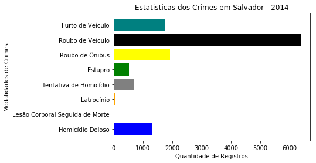

```python
locations = [1, 2, 3, 4, 5, 6, 7, 8]
heights = [(lista2014[0]), (lista2014[1]), (lista2014[2]), (lista2014[3]), (lista2014[4]), (lista2014[5]),
          (lista2014[6]), (lista2014[7])]
labels = ['Homicídio Doloso', 'Lesão Corporal Seguida de Morte', 'Latrocínio', 'Tentativa de Homicídio', 'Estupro',
          'Roubo de Ônibus', 'Roubo de Veículo', 'Furto de Veículo']
colors = ['blue', 'red', 'orange', 'gray', 'green', 'yellow', 'black', 'teal']
plt.barh(locations, heights, align='center', color= colors, ecolor='black',tick_label=labels )
plt.title('Estatisticas dos Crimes em Salvador - 2014')
plt.xlabel('Quantidade de Registros')
plt.ylabel('Modalidades de Crimes')
plt.width = 1.0
```

*Podemos perceber que no ano de 2014 a maior incidência de crime relatado foi o de Roubo de Veículo (6373 casos) seguido por Roubo de Ônibus (1929 casos) e Furto de Veículo (1752 casos). O crime de Homicídio Doloso teve um total de 1321 casos.*

```python
#Ano 2015
ano = 2015
total2015 = ds_total.query('ano == 2015 and aisp == "TOTAL DA CAPITAL"')
lista2015 = [total2015['homicídio doloso'].unique()[0], total2015['lesão corporal seguida de morte'].unique()[0],
             total2015['latrocínio'].unique()[0], total2015['tentativa de homicídio'].unique()[0],
             total2015['estupro'].unique()[0], total2015['roubo a ônibus'].unique()[0], total2015['roubo de veículo'].unique()[0],
             total2015['furto de veículo'].unique()[0]]

print("Total de Homicídio Doloso em 2015: {0}".format(lista2015[0]))
print("Total de Lesão Corporal seguida de Morte em 2015: {0}".format(lista2015[1]))
print("Total de Latrocínio em 2015: {0}".format(lista2015[2]))
print("Total de Tentativa de Homicídio em 2015: {0}".format(lista2015[3]))
print("Total de Estupro em 2015: {0}".format(lista2015[4]))
print("Total de Roubo de Ônibus em 2015: {0}".format(lista2015[5]))
print("Total de Roubo de Veículo em 2015: {0}".format(lista2015[6]))
print("Total de Furto de Veículo em 2015: {0}".format(lista2015[7]))
```

```
Total de Homicídio Doloso em 2015: 1.290
Total de Lesão Corporal seguida de Morte em 2015: 38
Total de Latrocínio em 2015: 64
Total de Tentativa de Homicídio em 2015: 561
Total de Estupro em 2015: 531
Total de Roubo de Ônibus em 2015: 2.561
Total de Roubo de Veículo em 2015: 6.537
Total de Furto de Veículo em 2015: 1.717
```

```python
#Melhorando os valores
lista2015[0] = 1290
lista2015[1] = 38
lista2015[2] = 64
lista2015[3] = 561
lista2015[4] = 531
lista2015[5] = 2561
lista2015[6] = 6537
lista2015[7] = 1717
```

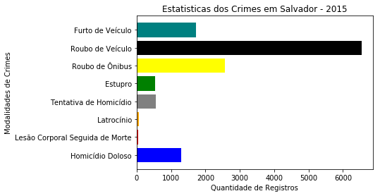

```python
locations = [1, 2, 3, 4, 5, 6, 7, 8]
heights = [(lista2015[0]), (lista2015[1]), (lista2015[2]), (lista2015[3]), (lista2015[4]), (lista2015[5]),
          (lista2015[6]), (lista2015[7])]
labels = ['Homicídio Doloso', 'Lesão Corporal Seguida de Morte', 'Latrocínio', 'Tentativa de Homicídio', 'Estupro',
          'Roubo de Ônibus', 'Roubo de Veículo', 'Furto de Veículo']
colors = ['blue', 'red', 'orange', 'gray', 'green', 'yellow', 'black', 'teal']
plt.barh(locations, heights, align='center', color= colors, ecolor='black',tick_label=labels )
plt.title('Estatisticas dos Crimes em Salvador - 2015')
plt.xlabel('Quantidade de Registros')
plt.ylabel('Modalidades de Crimes')
plt.width = 1.0
```

*Podemos perceber que no ano de 2015 a maior incidência de crime relatado foi o de Roubo de Veículo (6537 casos) seguido por Roubo de Ônibus (2561 casos) e Furto de Veículo (1717 casos). O crime de Homicídio Doloso teve um total de 1290 casos.*

```python
#Ano 2016
ano = 2016
total2016 = ds_total.query('ano == 2016 and aisp == "TOTAL DA CAPITAL"')
lista2016 = [total2016['homicídio doloso'].unique()[0], total2016['lesão corporal seguida de morte'].unique()[0],
             total2016['latrocínio'].unique()[0], total2016['tentativa de homicídio'].unique()[0],
             total2016['estupro'].unique()[0], total2016['roubo a ônibus'].unique()[0], total2016['roubo de veículo'].unique()[0],
             total2016['furto de veículo'].unique()[0]]

print("Total de Homicídio Doloso em 2016: {0}".format(lista2016[0]))
print("Total de Lesão Corporal seguida de Morte em 2016: {0}".format(lista2016[1]))
print("Total de Latrocínio em 2016: {0}".format(lista2016[2]))
print("Total de Tentativa de Homicídio em 2016: {0}".format(lista2016[3]))
print("Total de Estupro em 2016: {0}".format(lista2016[4]))
print("Total de Roubo de Ônibus em 2016: {0}".format(lista2016[5]))
print("Total de Roubo de Veículo em 2016: {0}".format(lista2016[6]))
print("Total de Furto de Veículo em 2016: {0}".format(lista2016[7]))
```

```
Total de Homicídio Doloso em 2016: 1.289
Total de Lesão Corporal seguida de Morte em 2016: 22
Total de Latrocínio em 2016: 38
Total de Tentativa de Homicídio em 2016: 469
Total de Estupro em 2016: 447
Total de Roubo de Ônibus em 2016: 2.615
Total de Roubo de Veículo em 2016: 6.219
Total de Furto de Veículo em 2016: 1.642
```

```python
#Melhorando os valores
lista2016[0] = 1289
lista2016[1] = 22
lista2016[2] = 38
lista2016[3] = 469
lista2016[4] = 447
lista2016[5] = 2615
lista2016[6] = 6219
lista2016[7] = 1642
```

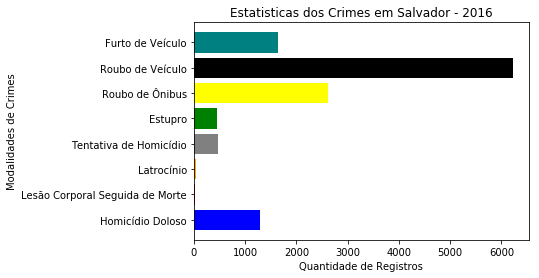

```python
locations = [1, 2, 3, 4, 5, 6, 7, 8]
heights = [(lista2016[0]), (lista2016[1]), (lista2016[2]), (lista2016[3]), (lista2016[4]), (lista2016[5]),
          (lista2016[6]), (lista2016[7])]
labels = ['Homicídio Doloso', 'Lesão Corporal Seguida de Morte', 'Latrocínio', 'Tentativa de Homicídio', 'Estupro',
          'Roubo de Ônibus', 'Roubo de Veículo', 'Furto de Veículo']
colors = ['blue', 'red', 'orange', 'gray', 'green', 'yellow', 'black', 'teal']
plt.barh(locations, heights, align='center', color= colors, ecolor='black',tick_label=labels )
plt.title('Estatisticas dos Crimes em Salvador - 2016')
plt.xlabel('Quantidade de Registros')
plt.ylabel('Modalidades de Crimes')
plt.width = 1.0
```

*Podemos perceber que no ano de 2016 a maior incidência de crime relatado foi o de Roubo de Veículo (6219 casos) seguido por Roubo de Ônibus (2615 casos) e Furto de Veículo (1642 casos). O crime de Homicídio Doloso teve um total de 1289 casos.*

```python
#Ano 2017
ano = 2017
total2017 = ds_total.query('ano == 2017 and aisp == "TOTAL DA CAPITAL"')
lista2017 = [total2017['homicídio doloso'].unique()[0], total2017['lesão corporal seguida de morte'].unique()[0],
             total2017['latrocínio'].unique()[0], total2017['tentativa de homicídio'].unique()[0],
             total2017['estupro'].unique()[0], total2017['roubo a ônibus'].unique()[0], total2017['roubo de veículo'].unique()[0],
             total2017['furto de veículo'].unique()[0]]

print("Total de Homicídio Doloso em 2017: {0}".format(lista2017[0]))
print("Total de Lesão Corporal seguida de Morte em 2017: {0}".format(lista2017[1]))
print("Total de Latrocínio em 2017: {0}".format(lista2017[2]))
print("Total de Tentativa de Homicídio em 2017: {0}".format(lista2017[3]))
print("Total de Estupro em 2017: {0}".format(lista2017[4]))
print("Total de Roubo de Ônibus em 2017: {0}".format(lista2017[5]))
print("Total de Roubo de Veículo em 2017: {0}".format(lista2017[6]))
print("Total de Furto de Veículo em 2017: {0}".format(lista2017[7]))
```

```
Total de Homicídio Doloso em 2017: 1.346
Total de Lesão Corporal seguida de Morte em 2017: 12
Total de Latrocínio em 2017: 36
Total de Tentativa de Homicídio em 2017: 523
Total de Estupro em 2017: 576
Total de Roubo de Ônibus em 2017: 2.615
Total de Roubo de Veículo em 2017: 5.733
Total de Furto de Veículo em 2017: 1.565
```

```python
#Melhorando os valores
lista2017[0] = 1346
lista2017[1] = 12
lista2017[2] = 36
lista2017[3] = 523
lista2017[4] = 576
lista2017[5] = 2615
lista2017[6] = 5733
lista2017[7] = 1565
```

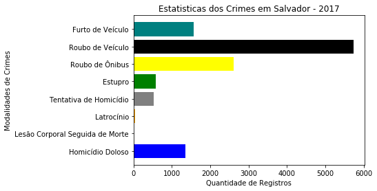

```python
locations = [1, 2, 3, 4, 5, 6, 7, 8]
heights = [(lista2017[0]), (lista2017[1]), (lista2017[2]), (lista2017[3]), (lista2017[4]), (lista2017[5]),
          (lista2017[6]), (lista2017[7])]
labels = ['Homicídio Doloso', 'Lesão Corporal Seguida de Morte', 'Latrocínio', 'Tentativa de Homicídio', 'Estupro',
          'Roubo de Ônibus', 'Roubo de Veículo', 'Furto de Veículo']
colors = ['blue', 'red', 'orange', 'gray', 'green', 'yellow', 'black', 'teal']
plt.barh(locations, heights, align='center', color= colors, ecolor='black',tick_label=labels )
plt.title('Estatisticas dos Crimes em Salvador - 2017')
plt.xlabel('Quantidade de Registros')
plt.ylabel('Modalidades de Crimes')
plt.width = 1.0
```

*Podemos perceber que no ano de 2017 a maior incidência de crime relatado foi o de Roubo de Veículo (5733 casos) seguido por Roubo de Ônibus (2615 casos) e Furto de Veículo (1565 casos). O crime de Homicídio Doloso teve um total de 1346 casos.*

```python
#Ano 2018
ano = 2018
total2018 = ds_total.query('ano == 2018 and aisp == "TOTAL DA CAPITAL"')
lista2018 = [total2018['homicídio doloso'].unique()[0], total2018['lesão corporal seguida de morte'].unique()[0],
             total2018['latrocínio'].unique()[0], total2018['tentativa de homicídio'].unique()[0],
             total2018['estupro'].unique()[0], total2018['roubo a ônibus'].unique()[0], total2018['roubo de veículo'].unique()[0],
             total2018['furto de veículo'].unique()[0]]

print("Total de Homicídio Doloso em 2018: {0}".format(lista2018[0]))
print("Total de Lesão Corporal seguida de Morte em 2018: {0}".format(lista2018[1]))
print("Total de Latrocínio em 2018: {0}".format(lista2018[2]))
print("Total de Tentativa de Homicídio em 2018: {0}".format(lista2018[3]))
print("Total de Estupro em 2018: {0}".format(lista2018[4]))
print("Total de Roubo de Ônibus em 2018: {0}".format(lista2018[5]))
print("Total de Roubo de Veículo em 2018: {0}".format(lista2018[6]))
print("Total de Furto de Veículo em 2018: {0}".format(lista2018[7]))
```

```
Total de Homicídio Doloso em 2018: 284
Total de Lesão Corporal seguida de Morte em 2018: 1
Total de Latrocínio em 2018: 2
Total de Tentativa de Homicídio em 2018: 91
Total de Estupro em 2018: 71
Total de Roubo de Ônibus em 2018: 471
Total de Roubo de Veículo em 2018: 1.425
Total de Furto de Veículo em 2018: 352
```

```python
#Melhorando os valores
lista2018[0] = 284
lista2018[1] = 1
lista2018[2] = 2
lista2018[3] = 91
lista2018[4] = 71
lista2018[5] = 471
lista2018[6] = 1425
lista2018[7] = 352
```

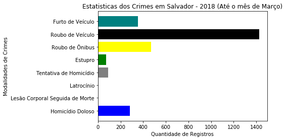

```python
locations = [1, 2, 3, 4, 5, 6, 7, 8]
heights = [(lista2018[0]), (lista2018[1]), (lista2018[2]), (lista2018[3]), (lista2018[4]), (lista2018[5]),
          (lista2018[6]), (lista2018[7])]
labels = ['Homicídio Doloso', 'Lesão Corporal Seguida de Morte', 'Latrocínio', 'Tentativa de Homicídio', 'Estupro',
          'Roubo de Ônibus', 'Roubo de Veículo', 'Furto de Veículo']
colors = ['blue', 'red', 'orange', 'gray', 'green', 'yellow', 'black', 'teal']
plt.barh(locations, heights, align='center', color= colors, ecolor='black',tick_label=labels )
plt.title('Estatisticas dos Crimes em Salvador - 2018 (Até o mês de Março)')
plt.xlabel('Quantidade de Registros')
plt.ylabel('Modalidades de Crimes')
plt.width = 1.0
```

*Podemos perceber que no ano de 2018 (até o mês de março) a maior incidência de crime relatado foi o de Roubo de Veículo (1425 casos) seguido por Roubo de Ônibus (471 casos) e Furto de Veículo (352 casos). O crime de Homicídio Doloso teve um total de 284 casos.*

**Qual a evolução por tipo de crime durante os períodos pesquisado(2014 a 2017)?**

```python
#Homicídio Doloso

print("Total de Homicídio Doloso em 2014: {0}".format(lista2014[0]))
print("Total de Homicídio Doloso em 2015: {0}".format(lista2015[0]))
print("Total de Homicídio Doloso em 2016: {0}".format(lista2016[0]))
print("Total de Homicídio Doloso em 2017: {0}".format(lista2017[0]))
```

```
Total de Homicídio Doloso em 2014: 1321
Total de Homicídio Doloso em 2015: 1290
Total de Homicídio Doloso em 2016: 1289
Total de Homicídio Doloso em 2017: 1346
```

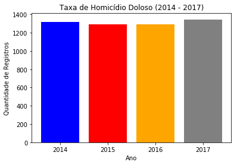

```python
locations = [1, 2, 3, 4]
heights = [(lista2014[0]), (lista2015[0]), (lista2016[0]), (lista2017[0])]
labels = ['2014', '2015', '2016', '2017']
colors = ['blue', 'red', 'orange', 'gray']
plt.bar(locations, heights, align='center', color= colors, ecolor='black',tick_label=labels )
plt.title('Taxa de Homicídio Doloso (2014 - 2017)')
plt.xlabel('Ano')
plt.ylabel('Quantidade de Registros')
plt.width = 1.0
```

*De 2014 para 2017 a taxa de Homicídio Doloso teve um aumento médio de 1,9% e de 2016 para 2017 teve um aumento médio de 4,4%.*

```python
#Lesão Corporal Seguida de Morte
print("Total de Lesão Corporal Seguida de Morte em 2014: {0}".format(lista2014[1]))
print("Total de Lesão Corporal Seguida de Morte em 2015: {0}".format(lista2015[1]))
print("Total de Lesão Corporal Seguida de Morte em 2016: {0}".format(lista2016[1]))
print("Total de Lesão Corporal Seguida de Morte em 2017: {0}".format(lista2017[1]))
```

```
Total de Lesão Corporal Seguida de Morte em 2014: 26
Total de Lesão Corporal Seguida de Morte em 2015: 38
Total de Lesão Corporal Seguida de Morte em 2016: 22
Total de Lesão Corporal Seguida de Morte em 2017: 12
```

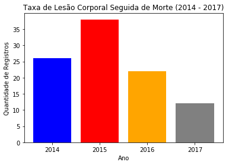

```python
locations = [1, 2, 3, 4]
heights = [(lista2014[1]), (lista2015[1]), (lista2016[1]), (lista2017[1])]
labels = ['2014', '2015', '2016', '2017']
colors = ['blue', 'red', 'orange', 'gray']
plt.bar(locations, heights, align='center', color= colors, ecolor='black',tick_label=labels )
plt.title('Taxa de Lesão Corporal Seguida de Morte (2014 - 2017)')
plt.xlabel('Ano')
plt.ylabel('Quantidade de Registros')
plt.width = 1.0
```

*De 2014 para 2017 a taxa de Lesão Corporal Seguida de Morte teve uma redução média de 53,8% e de 2016 para 2017 teve uma redução média de 45,5%.*

```python
#Latrocínio

print("Total de Latrocínio em 2014: {0}".format(lista2014[2]))
print("Total de Latrocínio em 2015: {0}".format(lista2015[2]))
print("Total de Latrocínio em 2016: {0}".format(lista2016[2]))
print("Total de Latrocínio em 2017: {0}".format(lista2017[2]))
```

```
Total de Latrocínio em 2014: 50
Total de Latrocínio em 2015: 64
Total de Latrocínio em 2016: 38
Total de Latrocínio em 2017: 36
```

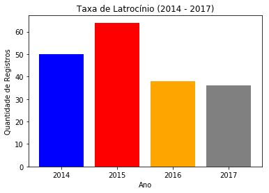

```python
locations = [1, 2, 3, 4]
heights = [(lista2014[2]), (lista2015[2]), (lista2016[2]), (lista2017[2])]
labels = ['2014', '2015', '2016', '2017']
colors = ['blue', 'red', 'orange', 'gray']
plt.bar(locations, heights, align='center', color= colors, ecolor='black',tick_label=labels )
plt.title('Taxa de Latrocínio (2014 - 2017)')
plt.xlabel('Ano')
plt.ylabel('Quantidade de Registros')
plt.width = 1.0
```

*De 2014 para 2017 a taxa Latrocínio teve uma redução média de 28% e de 2016 para 2017 teve uma redução média de 5,2%.*

```python
#Tentativa de Homicídio
print("Total de Tentativa de Homicídio em 2014: {0}".format(lista2014[3]))
print("Total de Tentativa de Homicídio em 2015: {0}".format(lista2015[3]))
print("Total de Tentativa de Homicídio em 2016: {0}".format(lista2016[3]))
print("Total de Tentativa de Homicídio em 2017: {0}".format(lista2017[3]))
```

```
Total de Tentativa de Homicídio em 2014: 712
Total de Tentativa de Homicídio em 2015: 561
Total de Tentativa de Homicídio em 2016: 469
Total de Tentativa de Homicídio em 2017: 523
```

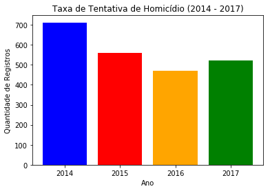

```python
locations = [1, 2, 3, 4]
heights = [(lista2014[3]), (lista2015[3]), (lista2016[3]), (lista2017[3])]
labels = ['2014', '2015', '2016', '2017']
colors = ['blue', 'red', 'orange', 'green']
plt.bar(locations, heights, align='center', color= colors, ecolor='black',tick_label=labels )
plt.title('Taxa de Tentativa de Homicídio (2014 - 2017)')
plt.xlabel('Ano')
plt.ylabel('Quantidade de Registros')
plt.width = 1.0
```

*De 2014 para 2017 a taxa Tentativa de Homicídio teve uma redução média de 26,5% e de 2016 para 2017 teve um aumento médio de 11,5%.*

```python
#Estupro

print("Total de Estupro em 2014: {0}".format(lista2014[4]))
print("Total de Estupro em 2015: {0}".format(lista2015[4]))
print("Total de Estupro em 2016: {0}".format(lista2016[4]))
print("Total de Estupro em 2017: {0}".format(lista2017[4]))
```

```
Total de Estupro em 2014: 532
Total de Estupro em 2015: 531
Total de Estupro em 2016: 447
Total de Estupro em 2017: 576
```

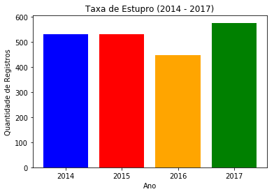

```python
locations = [1, 2, 3, 4]
heights = [(lista2014[4]), (lista2015[4]), (lista2016[4]), (lista2017[4])]
labels = ['2014', '2015', '2016', '2017']
colors = ['blue', 'red', 'orange', 'green']
plt.bar(locations, heights, align='center', color= colors, ecolor='black',tick_label=labels )
plt.title('Taxa de Estupro (2014 - 2017)')
plt.xlabel('Ano')
plt.ylabel('Quantidade de Registros')
plt.width = 1.0
```

*De 2014 para 2017 a taxa Estupro teve um aumento médio de 8,2% e de 2016 para 2017 teve um aumento médio de 28,9%.*

```python
#Roubo de Ônibus

print("Total de Roubo de Ônibus em 2014: {0}".format(lista2014[5]))
print("Total de Roubo de Ônibus em 2015: {0}".format(lista2015[5]))
print("Total de Roubo de Ônibus em 2016: {0}".format(lista2016[5]))
print("Total de Roubo de Ônibus em 2017: {0}".format(lista2017[5]))
```

```
Total de Roubo de Ônibus em 2014: 1929
Total de Roubo de Ônibus em 2015: 2561
Total de Roubo de Ônibus em 2016: 2615
Total de Roubo de Ônibus em 2017: 2615
```

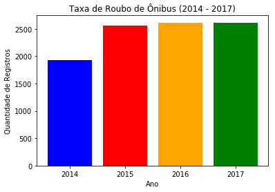

```python
locations = [1, 2, 3, 4]
heights = [(lista2014[5]), (lista2015[5]), (lista2016[5]), (lista2017[5])]
labels = ['2014', '2015', '2016', '2017']
colors = ['blue', 'red', 'orange', 'green']
plt.bar(locations, heights, align='center', color= colors, ecolor='black',tick_label=labels )
plt.title('Taxa de Roubo de Ônibus (2014 - 2017)')
plt.xlabel('Ano')
plt.ylabel('Quantidade de Registros')
plt.width = 1.0
```

*De 2014 para 2017 a taxa Roubo de ônibus teve um aumento médio de 35,5%.*

```python
#Roubo de Veículo

print("Total de Roubo de Veículo em 2014: {0}".format(lista2014[6]))
print("Total de Roubo de Veículo em 2015: {0}".format(lista2015[6]))
print("Total de Roubo de Veículo em 2016: {0}".format(lista2016[6]))
print("Total de Roubo de Veículo em 2017: {0}".format(lista2017[6]))
```

```
Total de Roubo de Veículo em 2014: 6373
Total de Roubo de Veículo em 2015: 6537
Total de Roubo de Veículo em 2016: 6219
Total de Roubo de Veículo em 2017: 5733
```

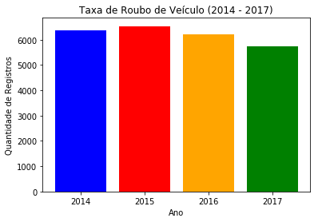

```python
locations = [1, 2, 3, 4]
heights = [(lista2014[6]), (lista2015[6]), (lista2016[6]), (lista2017[6])]
labels = ['2014', '2015', '2016', '2017']
colors = ['blue', 'red', 'orange', 'green']
plt.bar(locations, heights, align='center', color= colors, ecolor='black',tick_label=labels )
plt.title('Taxa de Roubo de Veículo (2014 - 2017)')
plt.xlabel('Ano')
plt.ylabel('Quantidade de Registros')
plt.width = 1.0
```

*De 2014 para 2017 a taxa Roubo de Veículo teve uma redução média de 10% e de 2016 para 2017 teve uma redução média de 7,8%.*

```python
#Furto de Veículo

print("Total de Furto de Veículo em 2014: {0}".format(lista2014[7]))
print("Total de Furto de Veículo em 2015: {0}".format(lista2015[7]))
print("Total de Furto de Veículo em 2016: {0}".format(lista2016[7]))
print("Total de Furto de Veículo em 2017: {0}".format(lista2017[7]))
```

```
Total de Furto de Veículo em 2014: 1752
Total de Furto de Veículo em 2015: 1717
Total de Furto de Veículo em 2016: 1642
Total de Furto de Veículo em 2017: 1565
```

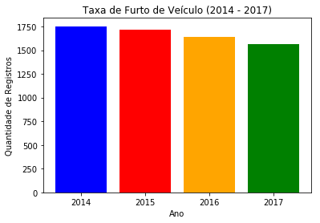

```python
locations = [1, 2, 3, 4]
heights = [(lista2014[7]), (lista2015[7]), (lista2016[7]), (lista2017[7])]
labels = ['2014', '2015', '2016', '2017']
colors = ['blue', 'red', 'orange', 'green']
plt.bar(locations, heights, align='center', color= colors, ecolor='black',tick_label=labels )
plt.title('Taxa de Furto de Veículo (2014 - 2017)')
plt.xlabel('Ano')
plt.ylabel('Quantidade de Registros')
plt.width = 1.0
```

*De 2014 para 2017 a taxa Furto de Veículo teve uma redução média de 10,7% e de 2016 para 2017 teve uma redução média de 4,7%.*

```python
#Quantidade total de crimes

print("Total de crimes em 2014: {0}".format(sum(lista2014)))
print("Total de crimes em 2015: {0}".format(sum(lista2015)))
print("Total de crimes em 2016: {0}".format(sum(lista2016)))
print("Total de crimes em 2017: {0}".format(sum(lista2017)))
```

```
Total de crimes em 2014: 12695
Total de crimes em 2015: 13299
Total de crimes em 2016: 12741
Total de crimes em 2017: 12406
```

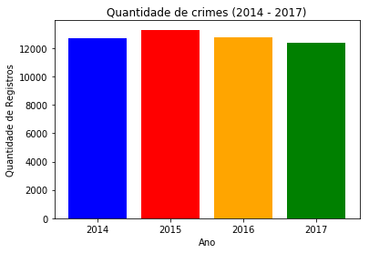

```python
locations = [1, 2, 3, 4]
heights = [(sum(lista2014)), (sum(lista2015)), (sum(lista2016)), (sum(lista2017))]
labels = ['2014', '2015', '2016', '2017']
colors = ['blue', 'red', 'orange', 'green']
plt.bar(locations, heights, align='center', color= colors, ecolor='black',tick_label=labels )
plt.title('Quantidade de crimes (2014 - 2017)')
plt.xlabel('Ano')
plt.ylabel('Quantidade de Registros')
plt.width = 1.0
```

**Qual o total de mortes nos anos de 2014 até 2017?**

```python
def qnt_mortes(lista):
    """Trazer o resultado do total de mortes por ano
      Argumentos:
          df: Lista/base de dados
      Retorna:
          Um valor inteiro com o total de mortes."""
    return lista[0] + lista[1] + lista[2]
```

```python
#Total de Mortes 2014
mortes_2014 = qnt_mortes(lista2014)
mortes_2015 = qnt_mortes(lista2015)
mortes_2016 = qnt_mortes(lista2016)
mortes_2017 = qnt_mortes(lista2017)

print("Total de mortes registradas em 2014: {0}".format(mortes_2014))
print("Total de mortes registradas em 2015: {0}".format(mortes_2015))
print("Total de mortes registradas em 2016: {0}".format(mortes_2016))
print("Total de mortes registradas em 2017: {0}".format(mortes_2017))
```

```
Total de mortes registradas em 2014: 1397
Total de mortes registradas em 2015: 1392
Total de mortes registradas em 2016: 1349
Total de mortes registradas em 2017: 1394
```

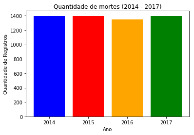

```python
locations = [1, 2, 3, 4]
heights = [mortes_2014, mortes_2015, mortes_2016, mortes_2017]
labels = ['2014', '2015', '2016', '2017']
colors = ['blue', 'red', 'orange', 'green']
plt.bar(locations, heights, align='center', color= colors, ecolor='black',tick_label=labels )
plt.title('Quantidade de mortes (2014 - 2017)')
plt.xlabel('Ano')
plt.ylabel('Quantidade de Registros')
plt.width = 1.0
```

*O número de mortes nesses quatro anos se manteve estável, de 2014 para 2017 teve uma redução de 0,2% no número de mortes, de 2016 para 2017 um aumento de 3,3%.*

## Conclusão

Podemos perceber que o ano de **2015** foi um dos mais violentos no municipío de Salvador com um total de **13299 casos de criminalidade**, em relação a **Homicidio** o ano mais violento foi o de **2017** com um total de **1346 casos** registrados, no quesito **estupro** o ano de **2017** também foi o mais violento com um total de **576 casos**. Em **2014** tivemos o total de **1397 casos de assassinato** enquanto que em **2017** tivemos um total de **1394 casos**, o número de casos de assassinato se manteve muito estável nos quatro anos analisados.